# T3 - Summary Paper - CROSS SELL Analytics

T3 - Linear Boost

2021-11-07

# 1 Introduction

What is Cross-Sell?

Cross-selling in insurance is the act of promoting products that are related or complementary to the one(s) your current customers already own or use. It is one of the most effective methods of marketing.

Client Profile:

An insurance company that provides medical insurance to its customers wants to know how many of their existing policyholders (customers) from last year will also be interested in Vehicle Insurance provided by the company.

1. What is an Insurance Policy? An insurance policy is an arrangement by which a company undertakes to provide a guarantee of compensation for specified loss, damage, illness, or death in return for the payment of a specified premium. A premium is a sum of money that the customer needs to pay regularly to an insurance company for this guarantee.
2. What is Vehicle Insurance? Vehicle insurance is insurance for cars, trucks, motorcycles, and other road vehicles where every year customer needs to pay a premium of certain amount to insurance provider so that they provide financial protection against physical damage or bodily injury resulting from traffic collisions and against liability that could also arise from incidents in a vehicle.

# 2 SMART Problem

Whether a customer would be interested in an additional insurance service like vehicle Insurance is extremely helpful for the company because it can then accordingly plan its communication strategy to reach out to those customers and optimize its business model and revenue. We have following information to assist our analysis: demographics (gender, age, region code type), Vehicles (Vehicle Age, Damage), Policy (Premium, sourcing channel) etc.

### 2.0.1 Why did we choose this topic?

Insurance was a familiar field to our team and cross-selling is a widely used strategy in insurance market. Hence, we decided to pursue cross-sell analytics.

### 2.0.2 What prior research and analysis have been done on this topic?

We were trying to find some effective ways to understand the cross selling in detail and we came across following links:

https://www.yieldify.com/blog/cross-selling/ https://www.podium.com/article/cross-selling/ https://www.business.com/articles/how-to-boost-sales-with-cross-selling-and-cross-promotion/

### 2.0.3 Your SMART questions, and how did they come up?

After studying the data set, we realized which attributes contribute to the response of the customer. Following that we formulated our SMART question and sub-SMART questions around response.

### 2.0.4 After the EDA, did your questions change? If so, how?

Our SMART questions didn’t change but we modified them a little to better project the impact of independent attributes on the “Response” of customer.

This report is organized as follows:

1. Description of the Data (explanation of the dataset and its variables)
2. EDA - Target variable and Independent variable
3. Hypothesis Testing: t-Test & Chi-Square
4. Conclusion

# 3 Cross-Sell RAW Data - Description

Column Name Column Description id Unique ID for the customer Gender Gender of the customer Age Age of the customer Driving_License 0: No License; 1: Valid License Region_Code Unique code for the region Previously_Insured 0: No Vehicle Insurance; 1: Existing Vehicle Insurance Vehicle_Age Age of the vehicle Vehicle_Damage 0: Vehicle has been damaged in the past; 1: No damage to the vehicle Annual_Premium Amount of premium customer has to pay Policy_Sales_Channel Anonymous code for the channel of outreaching to the customer Vintage Number of days customer has been associated with the company Response 0: Customer is not interested; 1: Customer is interested

For our exploratory data analysis, we ignored “id” because this is a independent variable with no relation to customers “Response”.

# 4 Exploratory Data Analysis

## 4.1 Response Variable Trend

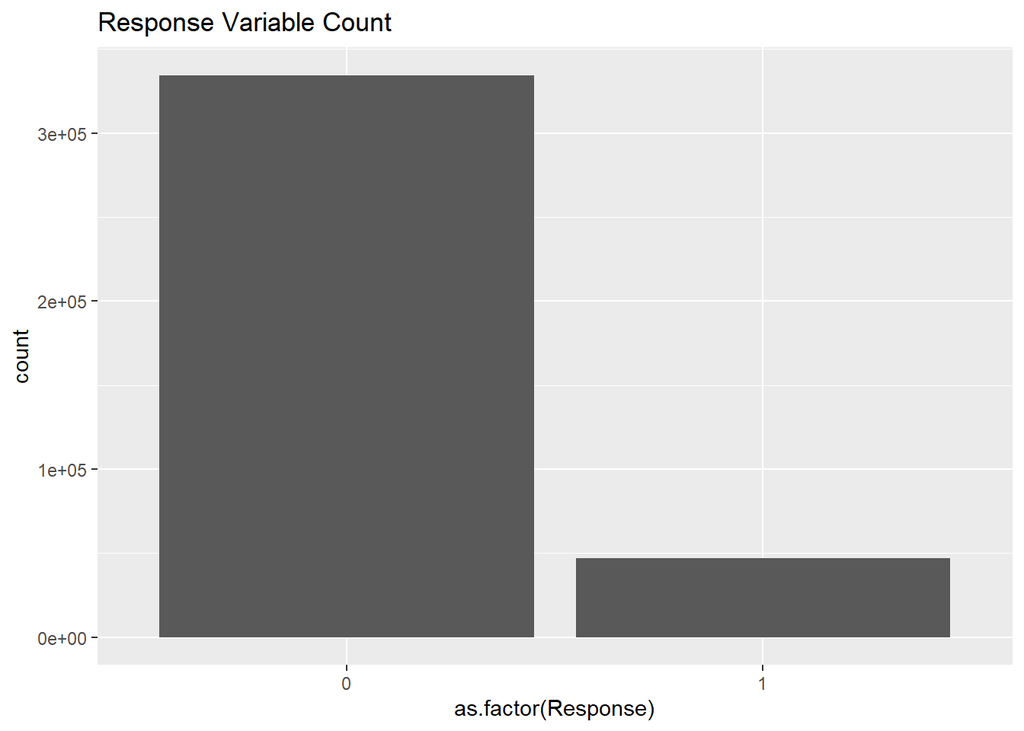

From the plot we can say that there’s imbalance in response. The individuals interested in purchasing a vehicle insurance are only 12.6%.

## 4.2 TREND OF ALL FEATURES IN DATASET WITH RESPONSE

### 4.2.1 Age v/s Response

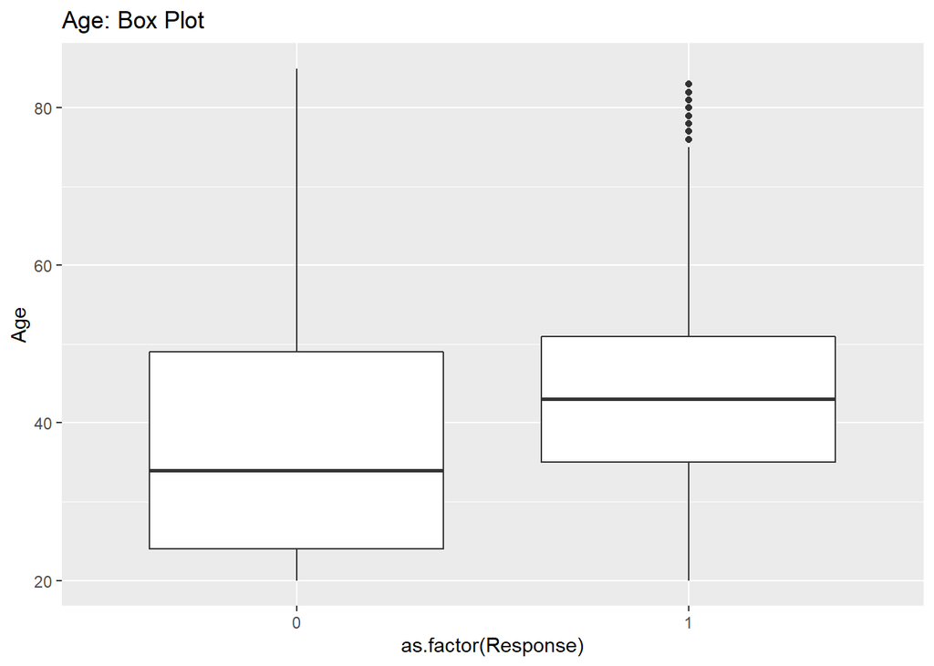

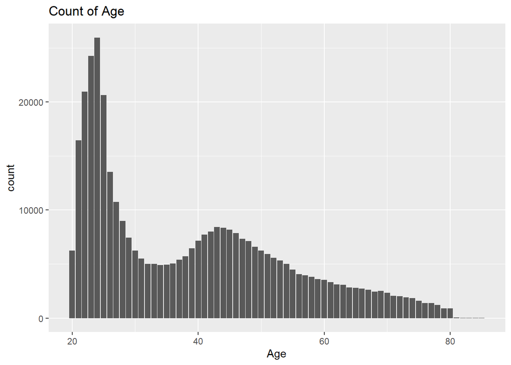

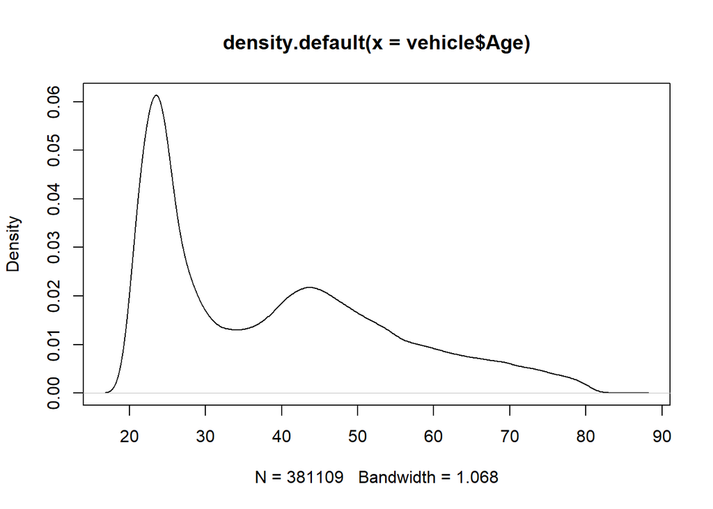

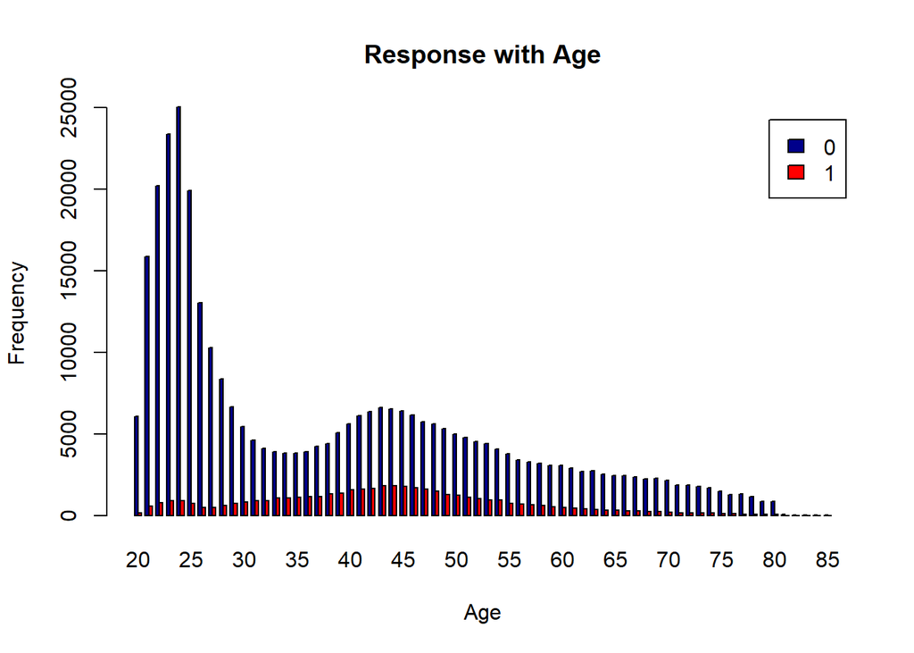

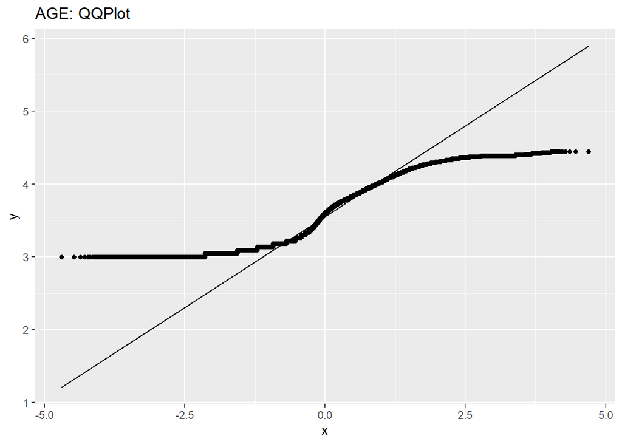

### 4.2.2 Gender v/s Response

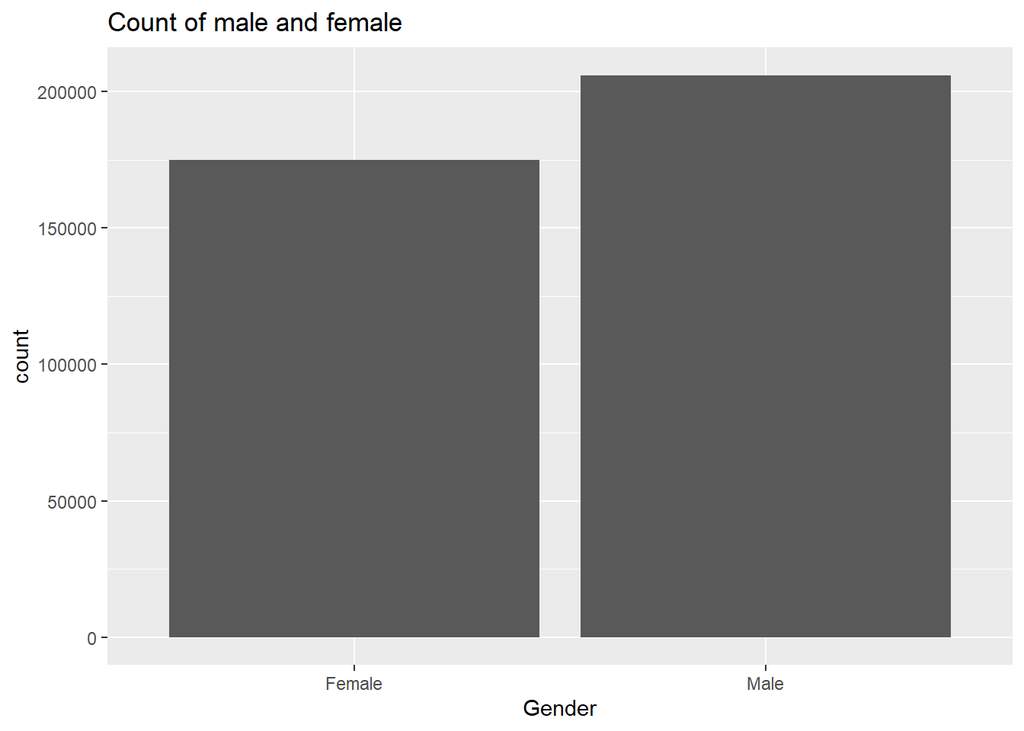

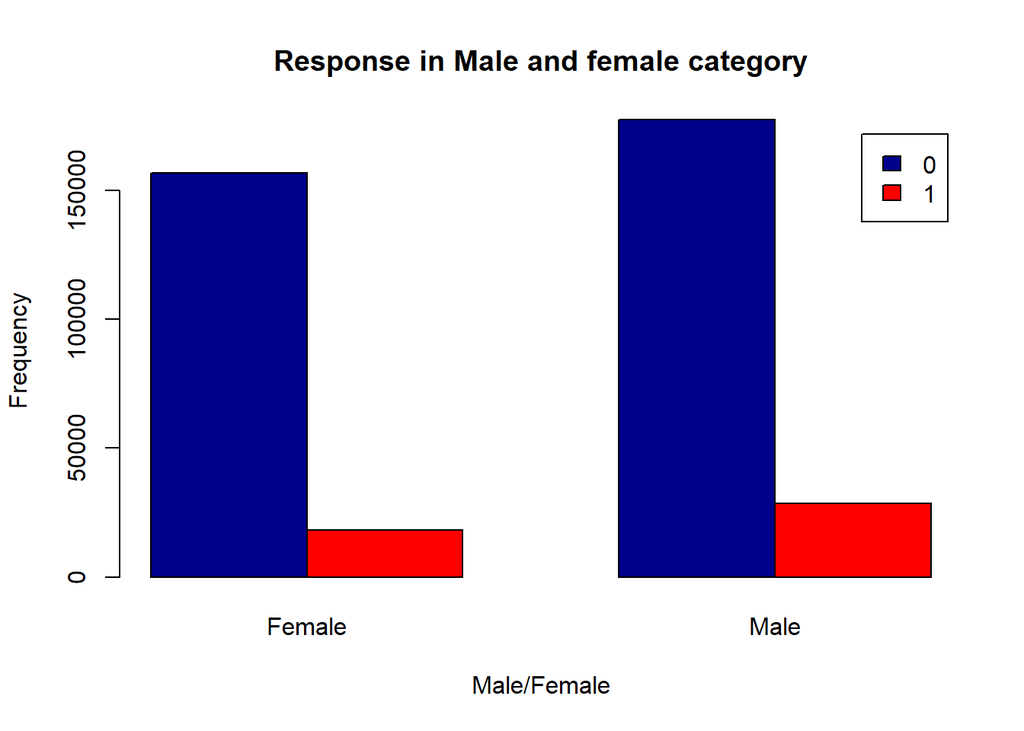

Male category is slightly greater than that of female and chances of buying the insurance is also little high

### 4.2.3 Vehicle Damage v/s Response

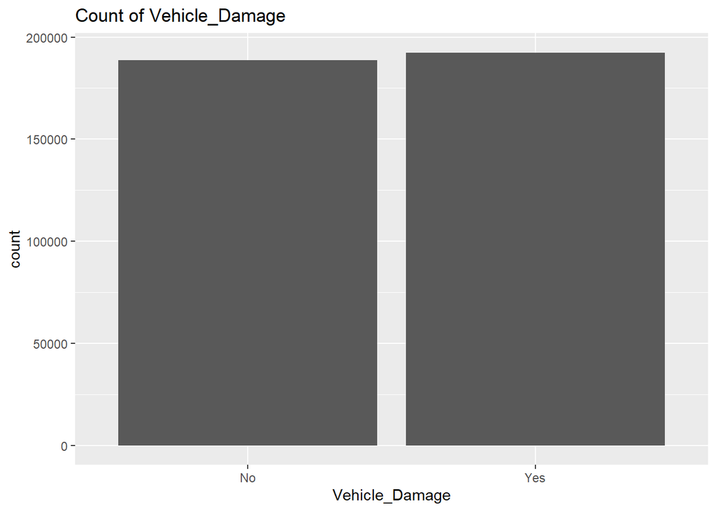

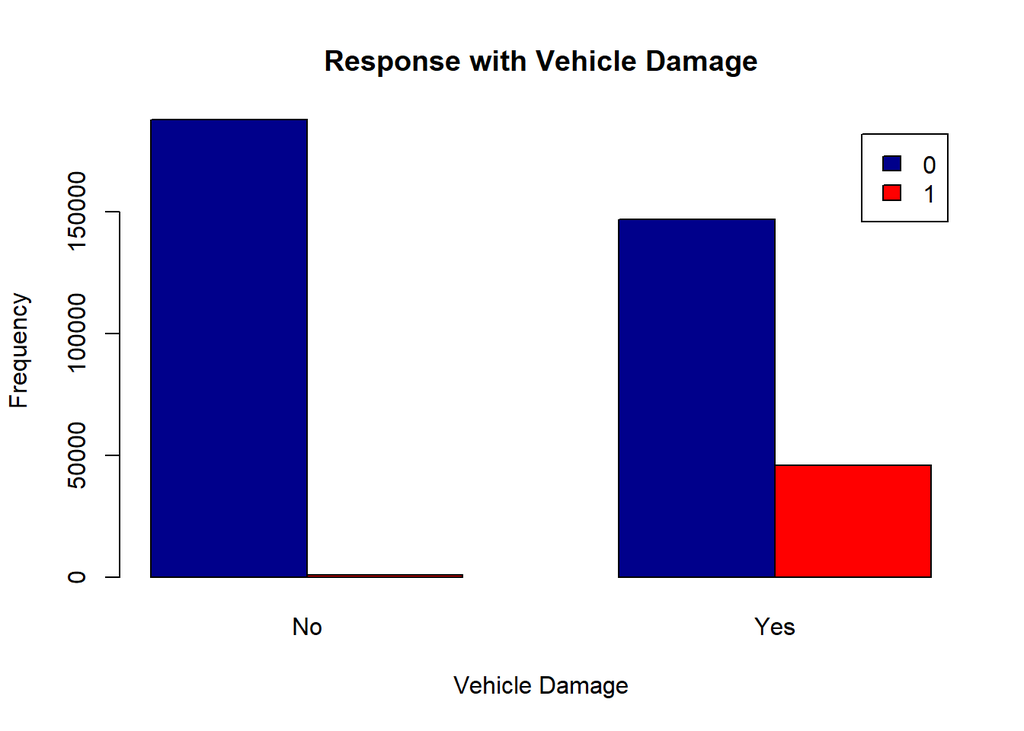

The distribution of customers with or without vehicle damage is almost same. The ones with vehicle damage are more interested in vehicle insurance.

### 4.2.4 Region Code v/s Response

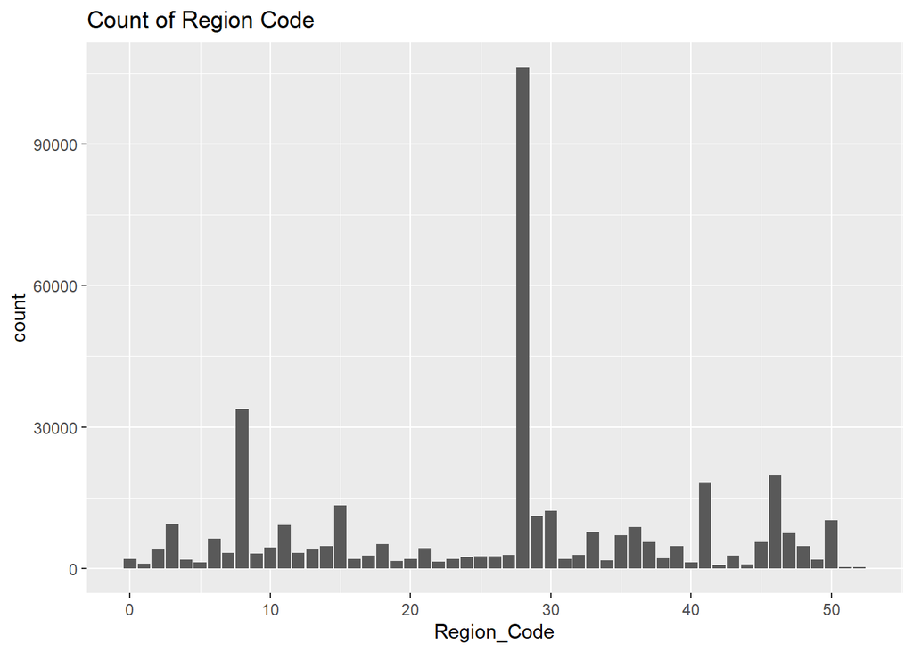

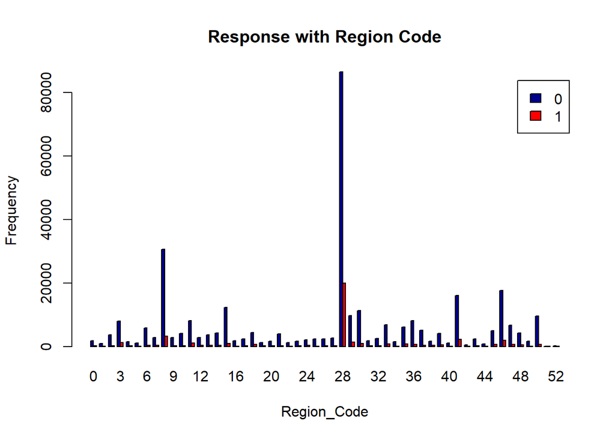

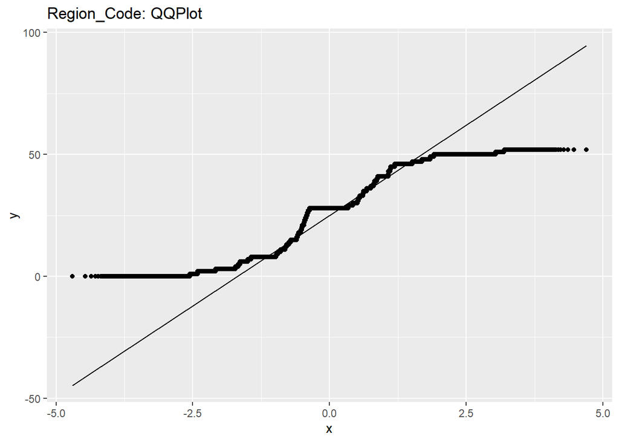

Region Code 28 seems to have highest customers and also the highest customers interested in vehicle insurance.

### 4.2.5 Driving License v/s Response

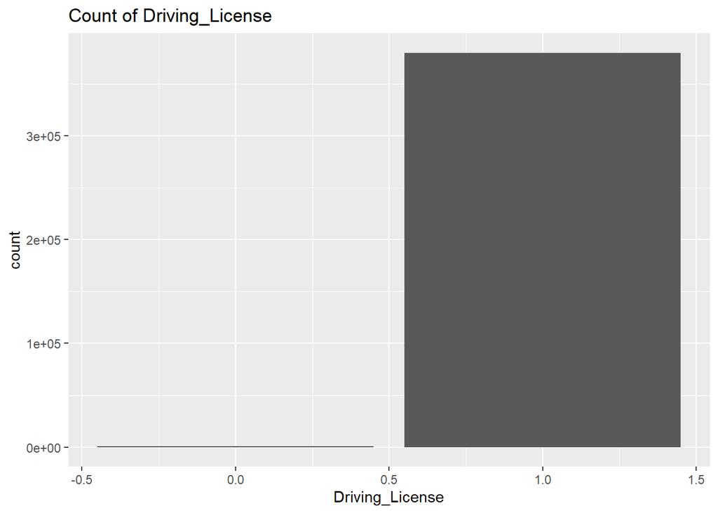

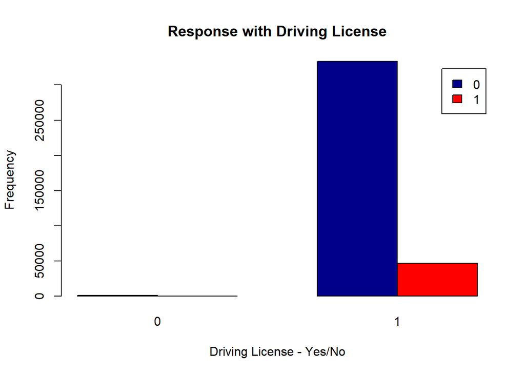

99% of customers have driving license and customers interested in Vehicle Insurance have driving license

### 4.2.6 Previously Insured v/s Response

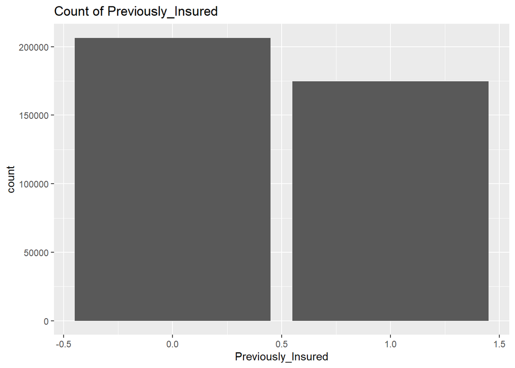

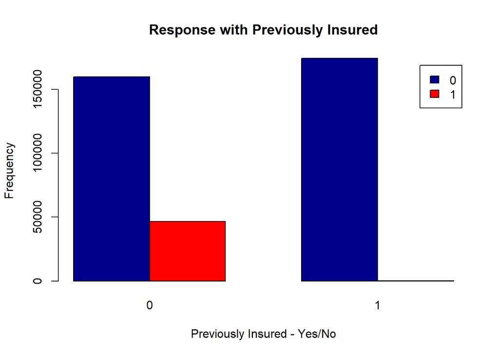

Customer who don’t have an insurance are higher in number than those who have insurance. Also they are more likely to buy the insurance.

### 4.2.7 Vehicle Age v/s Response

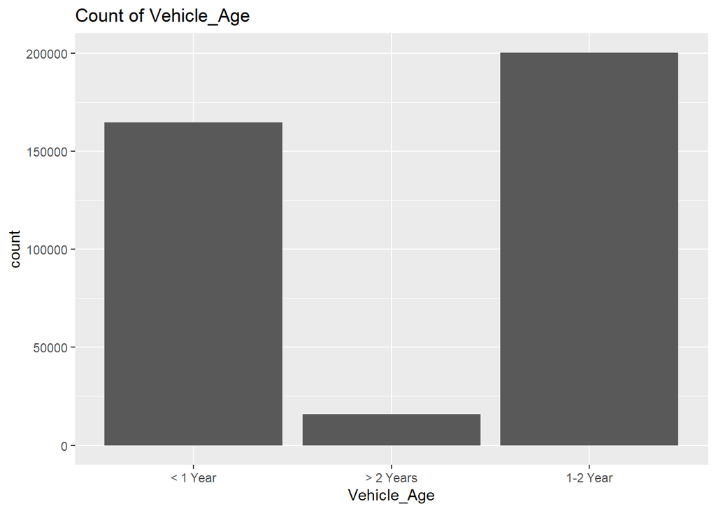

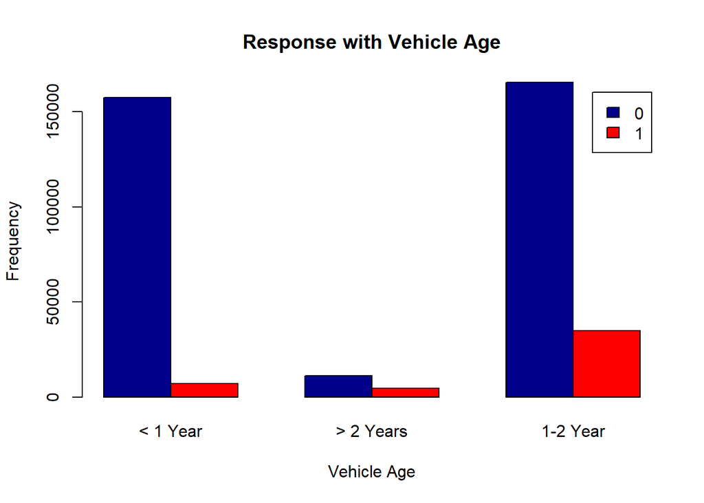

Customer who own a vehicle for more than 2 years are not many but some of them are interested in getting vehicle insurance. Mostly customers with vehicle for 1-2 years are interested in vehicle insurance.

### 4.2.8 Policy Sales Channel v/s Response

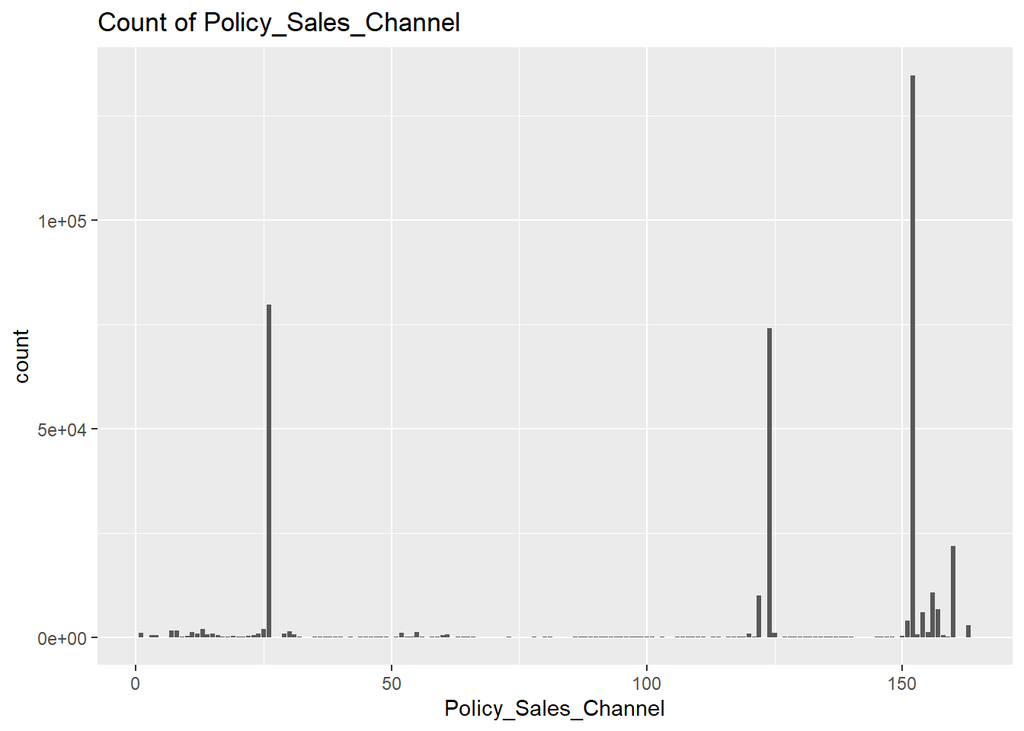

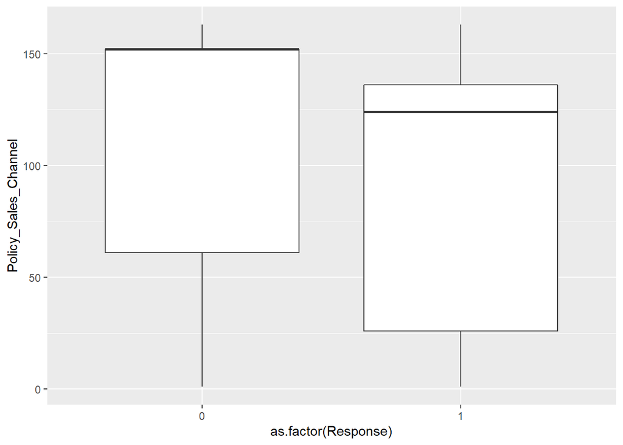

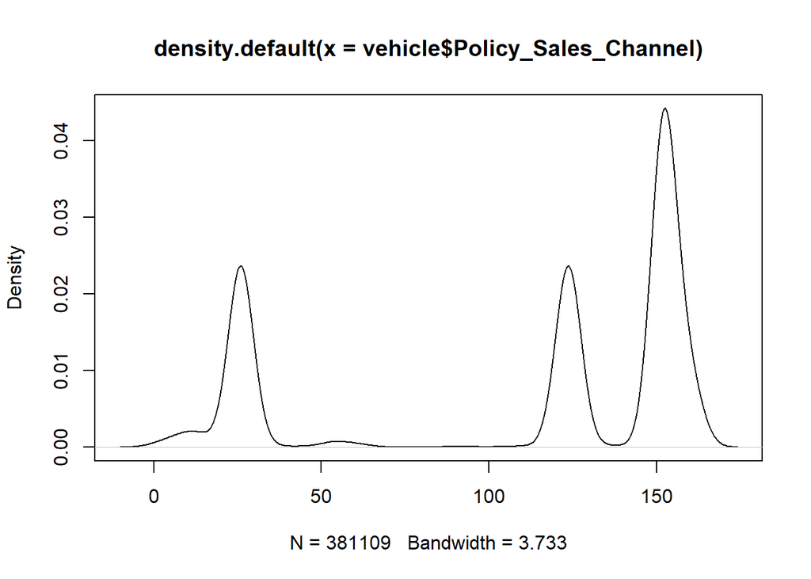

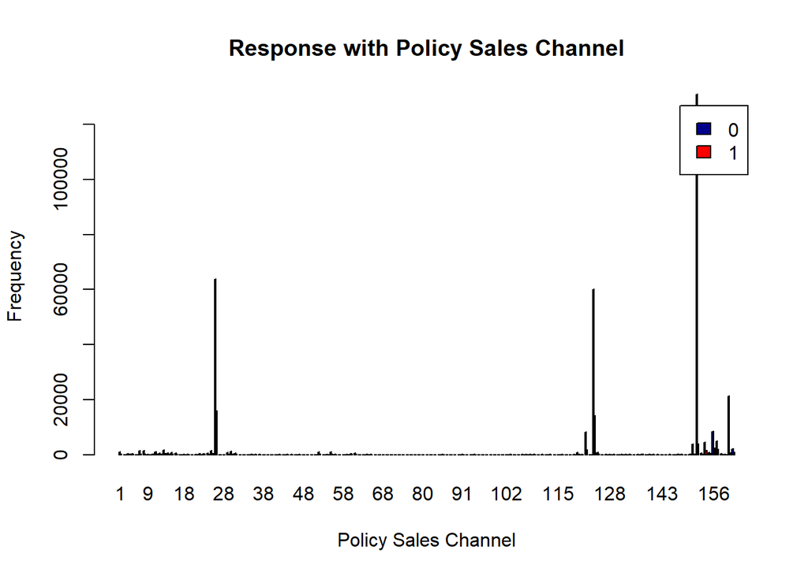

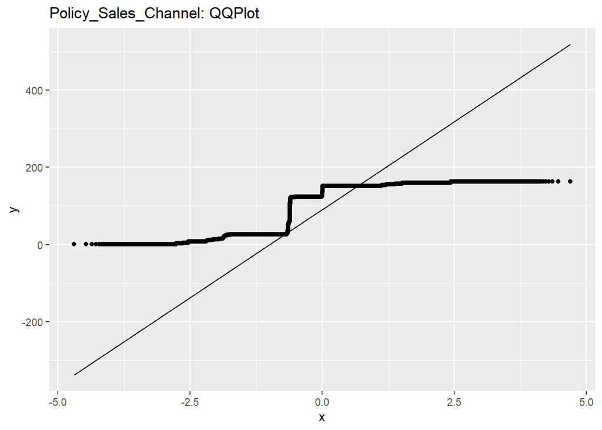

### 4.2.9 Annual Premium v/s Response

[figure not shown]

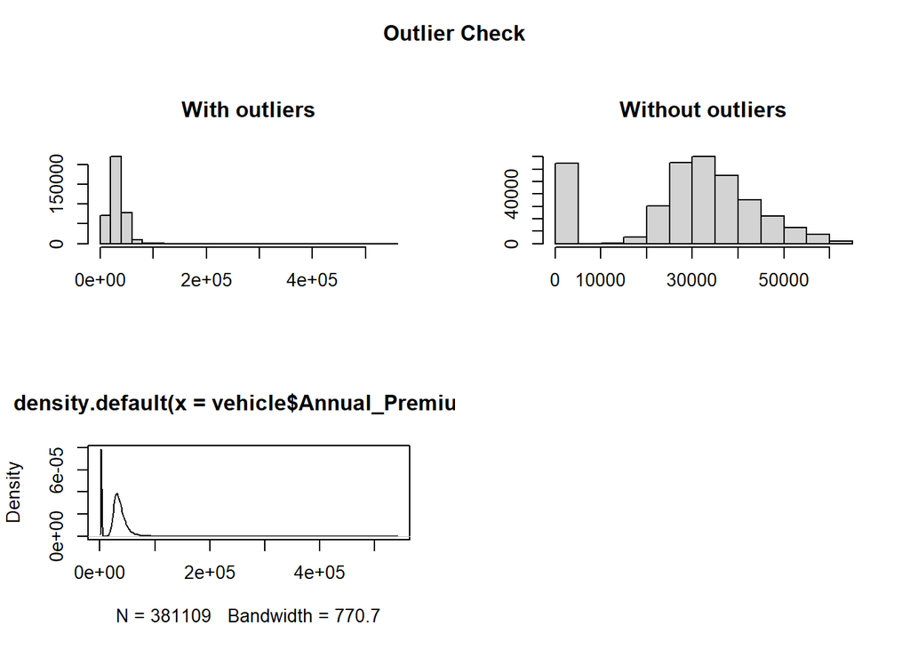

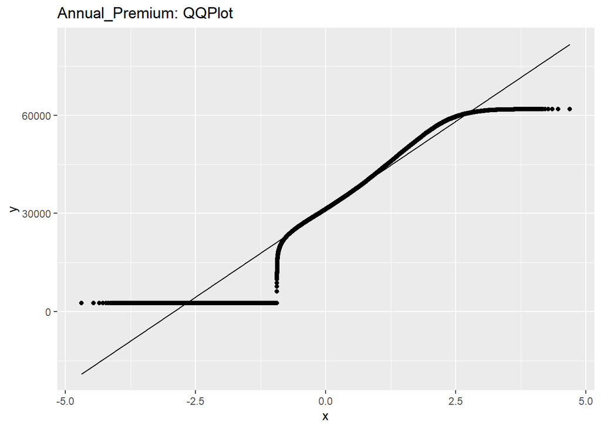

We can see from graph comparison above that there are a lot of outliers in for Annual Premium. We remove them and see what trend emerges.

### 4.2.10 Vintage v/s Response

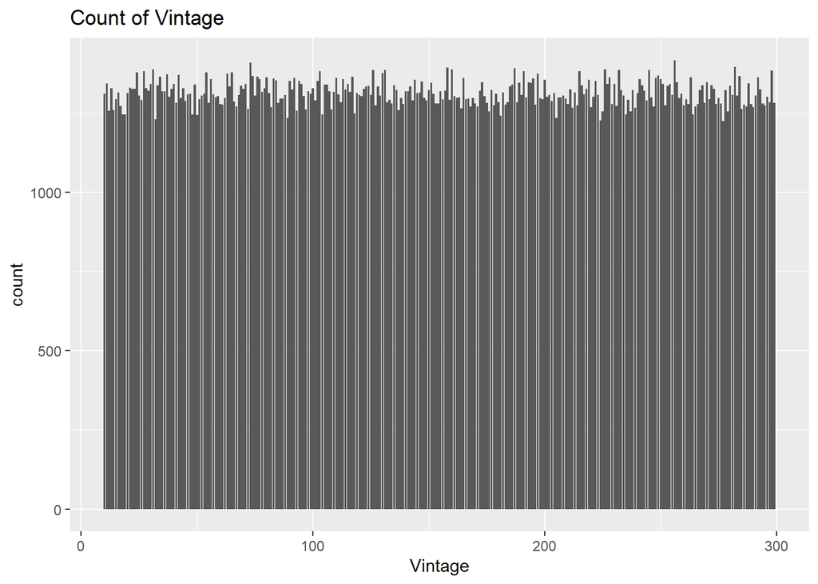

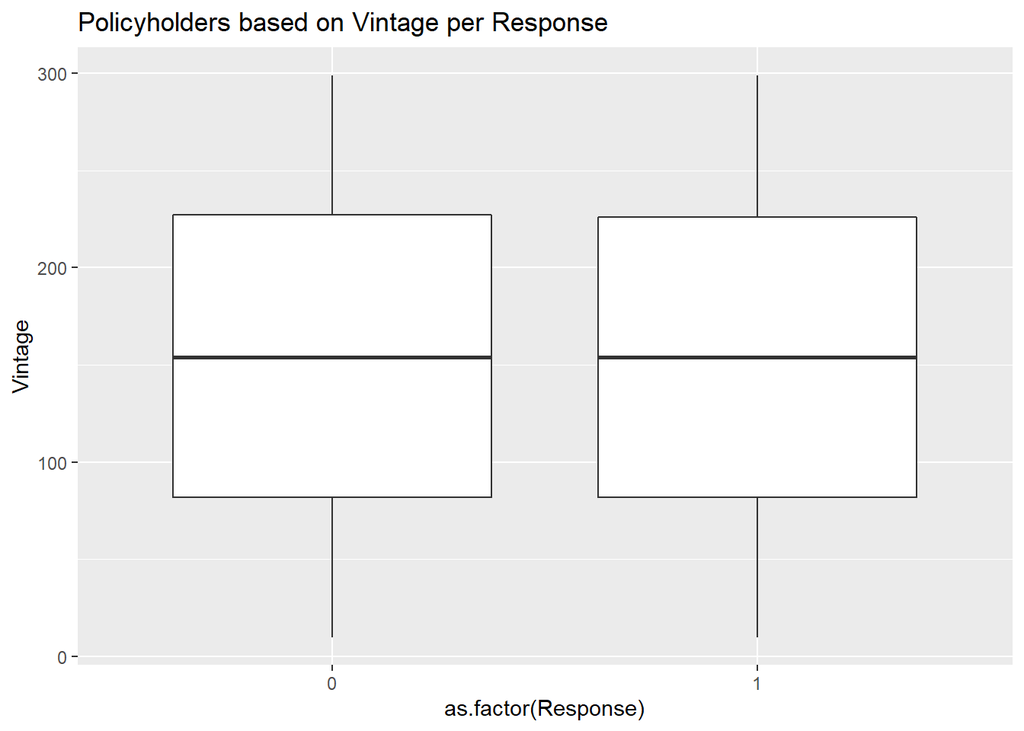

[figure not shown]

Looking at the box-plot, we can see that the means are almost at the same level; that is why the variable is nos helpful because it does not discriminate between accepting and reject